# STA465 hw3

### SAR Spatial Error

```r
mod_sar_error <- spautolm(median_family_income ~ unemploy_rate + Total_Popu + ttc_rate, data=merged_neighborhoods, listw=sids_queen_w)
summary(mod_sar_error)
```

```
##
## Call: spautolm(formula = median_family_income ~ unemploy_rate + Total_Popu +
##     ttc_rate, data = merged_neighborhoods, listw = sids_queen_w)
##
## Residuals:
##      Min       1Q   Median       3Q      Max
## -45869.0  -7954.3  -1795.1   5444.5  62013.3
##
## Coefficients:
##                  Estimate  Std. Error z value  Pr(>|z|)
## (Intercept)    2.2543e+05  1.0654e+04 21.1595 < 2.2e-16
## unemploy_rate -5.2533e+03  6.9668e+02 -7.5405 4.685e-14
## Total_Popu    -2.8080e-01  1.4842e-01 -1.8919    0.0585
## ttc_rate      -4.8373e+05  7.7066e+04 -6.2768 3.455e-10
##
## Lambda: 0.76599 LR test value: 51.401 p-value: 7.5284e-13
## Numerical Hessian standard error of lambda: 0.071514
##
## Log likelihood: -1561.942
## ML residual variance (sigma squared): 248500000, (sigma: 15764)
## Number of observations: 140
## Number of parameters estimated: 6
## AIC: 3135.9
```

1. **What:** $Y = X\beta + \epsilon$, where $\epsilon = \lambda W \epsilon + \nu$. $\lambda$ is the spatial autoregressive term for the errors, W is the spatial weight matrix, and ν is iid errors
2. **How**:
   - $Y \sim MVN(X\beta, \Sigma_{\epsilon})$, where $\Sigma_{\epsilon} = \sigma^2 (I - \lambda W)^{-1} (I - \lambda W)^{-T}$.
   - The goal is to maximize the likelihood: $L(\lambda, \beta, \sigma^2 | Y, X) = -\frac{n}{2} \log(2 \pi \sigma^2) - \frac{1}{2 \sigma^2} (Y - X \beta)'(Y - X \beta) + \log |I - \lambda W|$
   - $\beta$,$\rho$,$\sigma$ are optimized by Newton-Raphson
   - AIC is 3135.9, lower than OLS and SAR Lag. A lower AIC indicates a better model fit.
3. **Description of parameters**
   - Intercept (2.2543e+05): median family income is 2.2543e+05, when the predictors are zero
   - unemploy_rate (-5.2533e+03): It’s statistically significant (p-value < 0.05), after accounting for spatial effects
   - Total_Popu (-2.8080e-01): It’s NOT statistically significant (p-value > 0.05), after accounting for spatial effects
   - ttc_rate (-4.8373e+05): It’s statistically significant (p-value < 0.05), after accounting for spatial effects
   - The spatial parameter $\lambda$ is 0.76599, and is statistically significant (p-value < 0.005). This suggests there are unobserved spatial factors that are influencing median family income across neighborhoods.
   - The associated likelihood ratio test is 51.401 and statistically significant (p-value < 0.05). This shows a higher likelihood for SAR Error Model. This indicates the median income is fitted better by SAR Error Model than the OLS model, because of the addition of the error term that accounts for spatial autocorrelation.
4. **Test residual**

```r
merged_neighborhoods$sar_error_resid<-residuals(mod_sar_error)
moran.test(merged_neighborhoods$sar_error_resid, listw=sids_queen_w)
```

```
##
##  Moran I test under randomisation
##
## data:  merged_neighborhoods$sar_error_resid
## weights: sids_queen_w
##
## Moran I statistic standard deviate = 1.5006, p-value = 0.06673
## alternative hypothesis: greater
## sample estimates:
## Moran I statistic       Expectation          Variance
##       0.065014886      -0.007194245       0.002315467
```

We can see Moran’s I is positive(0.065014886), and NOT statistically significant(p_value > 0.05). This suggests spatial autocorrelation is NOT present in the residuals, which means the SAR Spatial Error model does fully capture the spatial structure of the data. In other words, it captures both the effects of the predictors and the spatially structured unobserved factors that influence median family income across neighborhoods.

5. **Map the residual**

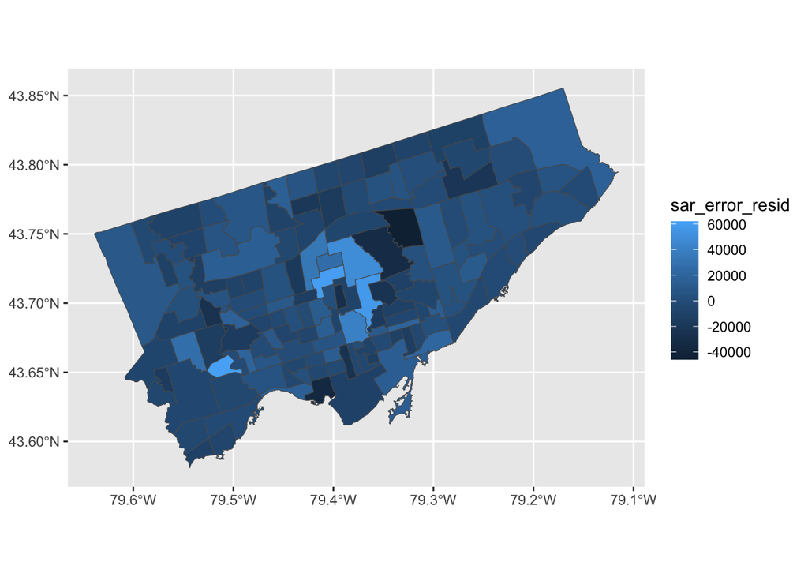

```r
ggplot(merged_neighborhoods) + geom_sf(aes(fill = sar_error_resid))
```

### SAR Spatial Lag-Error

```r
mod_sar_error_lag <- sacsarlm(median_family_income ~ unemploy_rate + Total_Popu + ttc_rate, data=merged_neighborhoods, listw=sids_queen_w)
summary(mod_sar_error_lag)
```

```
##
## Call:sacsarlm(formula = median_family_income ~ unemploy_rate + Total_Popu +
##     ttc_rate, data = merged_neighborhoods, listw = sids_queen_w)
##
## Residuals:
##      Min       1Q   Median       3Q      Max
## -45788.2  -8372.9  -1240.8   6944.8  59124.9
##
## Type: sac
## Coefficients: (numerical Hessian approximate standard errors)
##                  Estimate  Std. Error z value  Pr(>|z|)
## (Intercept)    1.8488e+05  1.5729e+04 11.7539 < 2.2e-16
## unemploy_rate -5.3155e+03  6.6903e+02 -7.9451 1.998e-15
## Total_Popu    -3.3095e-01  1.5232e-01 -2.1728    0.0298
## ttc_rate      -4.7106e+05  7.4047e+04 -6.3616 1.996e-10
##
## Rho: 0.36292
## Approximate (numerical Hessian) standard error: 0.094112
##     z-value: 3.8562, p-value: 0.00011515
## Lambda: 0.53746
## Approximate (numerical Hessian) standard error: 0.11979
##     z-value: 4.4865, p-value: 7.2398e-06
##
## LR test value: 61.493, p-value: 4.4298e-14
##
## Log likelihood: -1556.896 for sac model
## ML residual variance (sigma squared): 245460000, (sigma: 15667)
## Number of observations: 140
## Number of parameters estimated: 7
## AIC: 3127.8, (AIC for lm: 3185.3)
```

1. **What:** $Y = X\beta + \epsilon$. The spatial autocorrelation in both $Y$,$\epsilon$ is accounted. we estimate both $\rho$ and $\lambda$.
2. **How**:
   - The goal is to maximize the likelihood: $L(\rho, \lambda, \beta, \sigma^2 | Y, X) = -\frac{n}{2} \log(2 \pi \sigma^2) - \frac{1}{2 \sigma^2} \epsilon' \epsilon + \log |I - \rho W| + \log |I - \lambda W|$
   - $\beta$,$\rho$,$\sigma$ are optimized by Newton-Raphson
   - AIC is 3127.8, lower than OLS, SAR Lag and SAR Error. A lower AIC indicates a better model fit.
3. **Description of parameters**
   - Intercept (1.8488e+05): median family income is 1.8488e+05, when all the predictors are zero
   - unemploy_rate (-5.3155e+03): It’s statistically significant (p-value < 0.05), after accounting for spatial effects
   - Total_Popu (-3.3095e-01): It’s statistically significant (p-value < 0.05), after accounting for spatial effects
   - ttc_rate (-4.7106e+05): It’s statistically significant (p-value < 0.05), after accounting for spatial effects
   - The spatial lag parameter $\rho$ is 0.36292, and is statistically significant (p-value < 0.005). This positive value indicates that neighborhoods with high/low median incomes are likely to be near other neighborhoods with high/low median incomes.
   - The spatial error parameter $\lambda$ is 0.53746, and is statistically significant (p-value < 0.005). This suggests that there is spatial autocorrelation in the residuals. And there are unobserved spatial factors that are influencing median family income across neighborhoods.
   - The associated likelihood ratio test is 61.493 and statistically significant (p-value < 0.05). This shows a higher likelihood for SAR Lag-Error Model. This indicates the median income is fitted better by SAR Lag-Error Model than the OLS model, because it accounts for spatial autocorrelation both in the dependent variable and unobserved factors.
4. **Test residual**

```r
merged_neighborhoods$sar_error_lag_resid<-residuals(mod_sar_error_lag)
moran.test(merged_neighborhoods$sar_error_lag_resid, listw=sids_queen_w)
```

```
##
##  Moran I test under randomisation
##
## data:  merged_neighborhoods$sar_error_lag_resid
## weights: sids_queen_w
##
## Moran I statistic standard deviate = 0.74113, p-value = 0.2293
## alternative hypothesis: greater
## sample estimates:
## Moran I statistic       Expectation          Variance
##       0.028581170      -0.007194245       0.002330143
```

We can see Moran’s I is positive(0.028581170), and NOT statistically significant(p_value > 0.05). This suggests spatial autocorrelation is NOT present in the residuals, which means the SAR Lag-Error model does fully capture the spatial structure of the data. In other words, it captures spatial autocorrelation in both the dependent variable and the unobserved factors

5. **Map the residual**

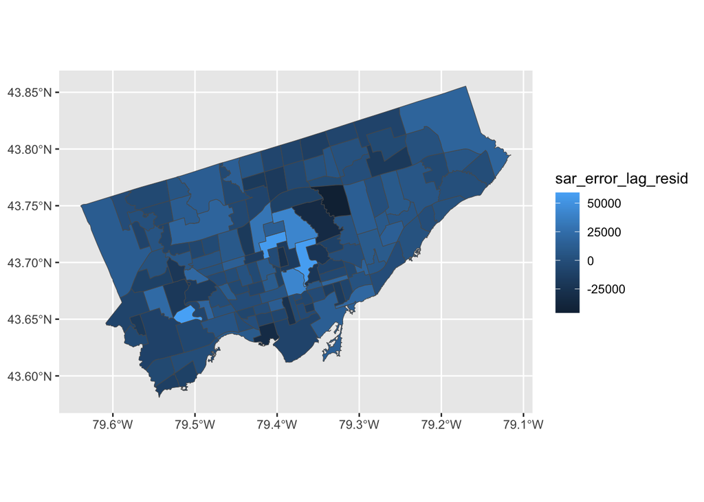

```r
ggplot(merged_neighborhoods) + geom_sf(aes(fill = sar_error_lag_resid))
```